# Chapter 15: Factors

```r
library(tidyverse)
library(forcats)
```

# 15.3 General Social Survey

## 15.3.1 Exercises

1. Explore the distribution of `rincome` (reported income). What makes the default bar chart hard to understand? How could you improve the plot?

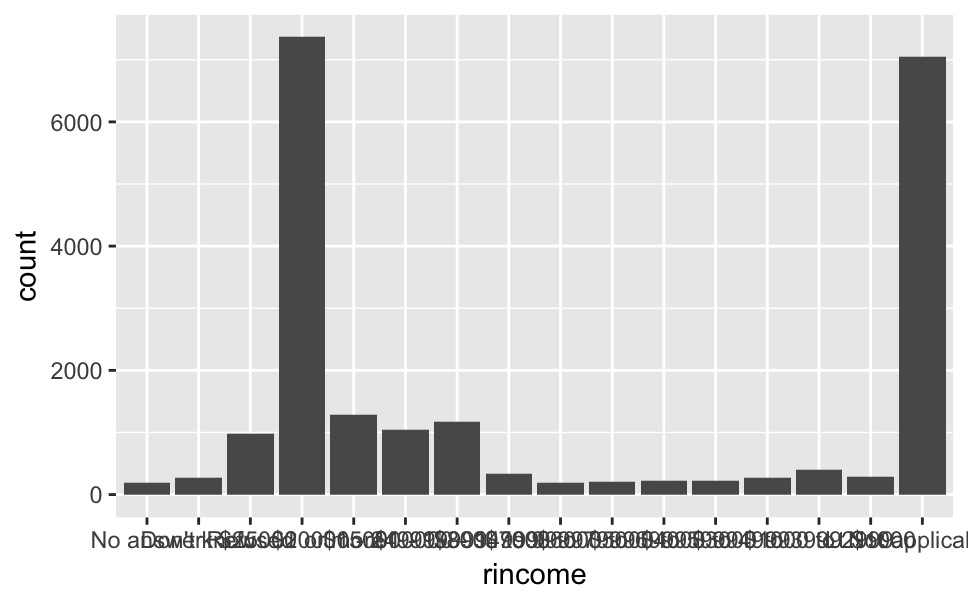

```r
gss_cat %>%
  ggplot(aes(rincome)) +
    geom_bar()
```

**The default x-axis labels aren’t easily readable because of the long category names Rotating the text 90 degrees should work - alternatively, the `ggstance` has horizontal plot options that might be worth a try.**

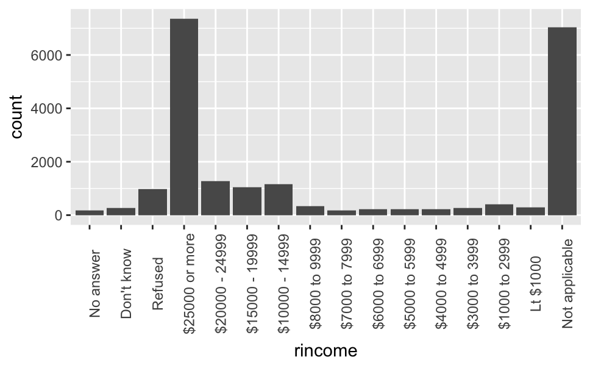

```r
gss_cat %>%
  ggplot(aes(rincome)) +
    geom_bar() +
    theme(axis.text.x  = element_text(angle=90))
```

2. What is the most common `relig` in this survey? What’s the most common `partyid`?

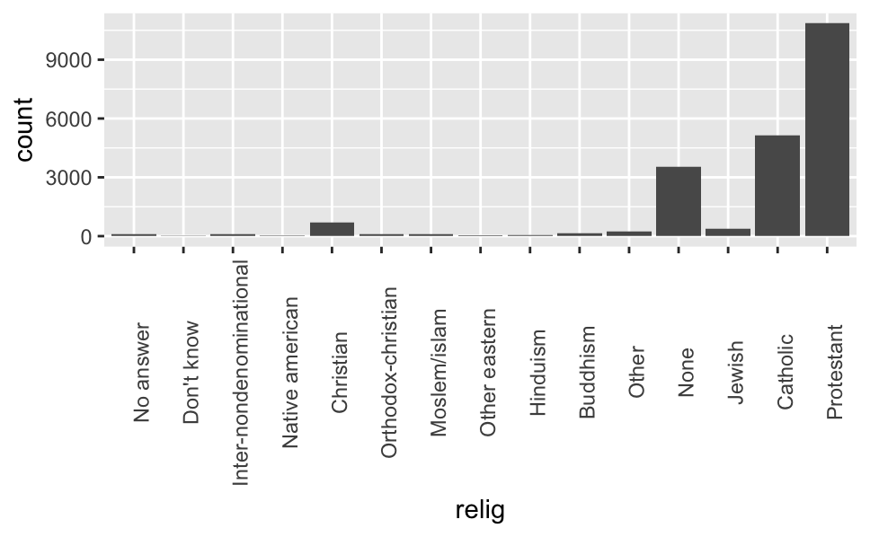

```r
gss_cat %>%
  ggplot(aes(relig)) +
    geom_bar() +
    theme(axis.text.x  = element_text(angle=90))
```

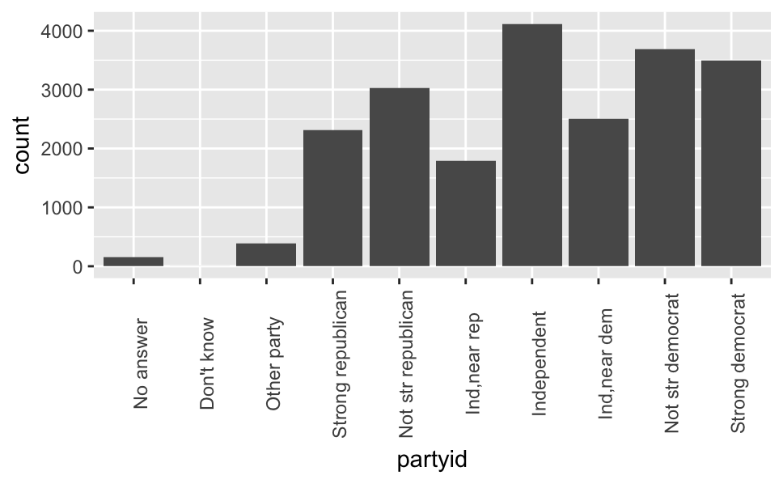

```r
gss_cat %>%
  ggplot(aes(partyid)) +
    geom_bar() +
    theme(axis.text.x  = element_text(angle=90))
```

**The most common religion is Protestant. The most common single response for party ID is Independent, but if groupings were combined based on strong + not-strong party affilitation things would look a bit different.**

3. Which `relig` does `denom` (denomination) apply to? How can you find out with a table? How can you find out with a visualisation?

```r
gss_cat %>%
  group_by(relig) %>%
  count(denom) %>%
  arrange(desc(n))
```

| relig | denom | n |
| --- | --- | --- |
| Catholic | Not applicable | 5124 |
| None | Not applicable | 3523 |
| Protestant | Other | 2534 |
| Protestant | Southern baptist | 1536 |
| Protestant | Baptist-dk which | 1457 |
| Protestant | No denomination | 1224 |
| Protestant | United methodist | 1067 |
| Christian | No denomination | 452 |
| Protestant | Episcopal | 397 |
| Jewish | Not applicable | 388 |

[output cut: 37 more lines]

**Denomination is primarily applicable for Protestant religious respondents.**

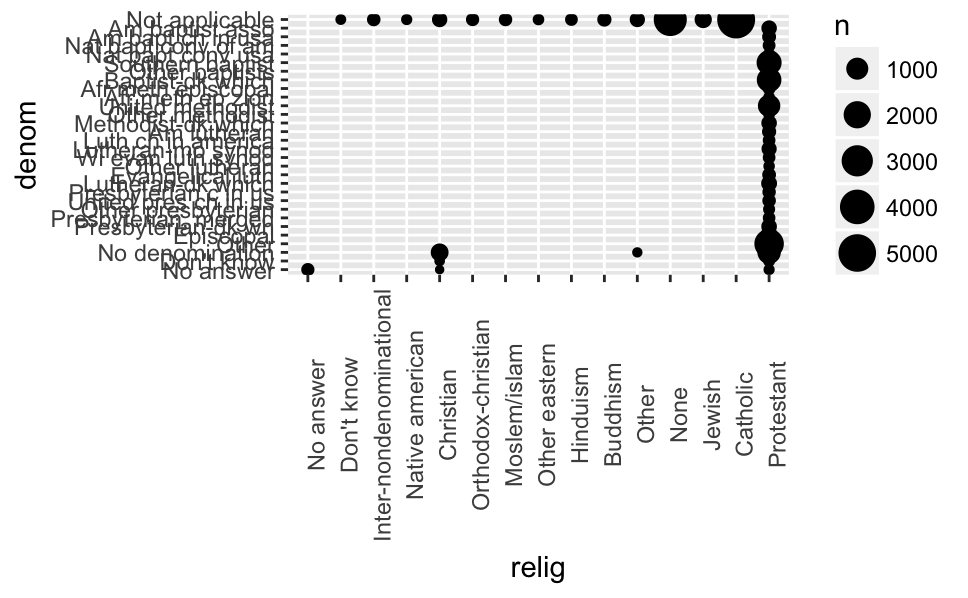

```r
gss_cat %>%
  ggplot(aes(x = relig, y = denom)) +
    geom_count() +
    theme(axis.text.x  = element_text(angle=90))
```

# 15.4 Modifying factor order

## 15.4.1 Exercises

1. There are some suspiciously high numbers in `tvhours`. Is the mean a good summary?

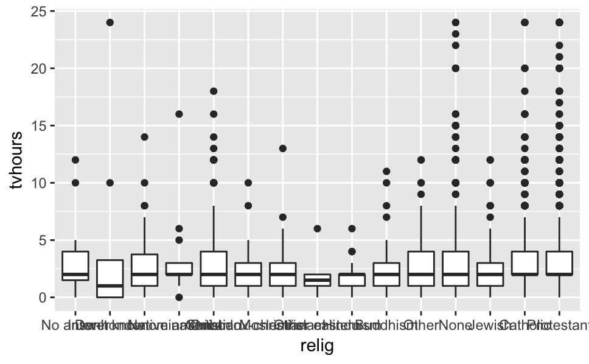

```r
gss_cat %>%
  ggplot(aes(x = relig, y = tvhours)) +
    geom_boxplot()
```

**The distribution appears to be quite skewed across most religions, so let’s look at using the median as a measure of central tendency instead.**

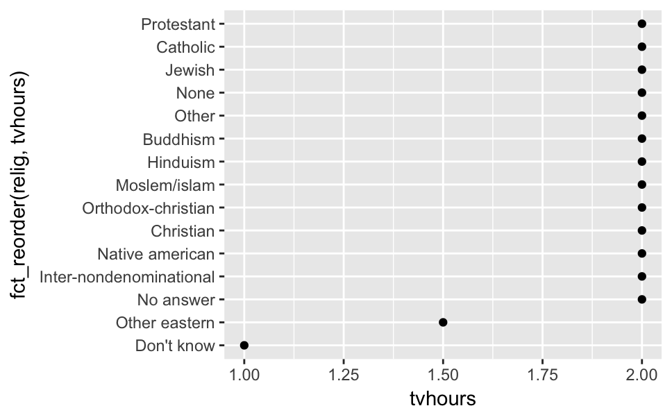

```r
relig <- gss_cat %>%
  group_by(relig) %>%
  summarise(
    age = mean(age, na.rm = TRUE),
    tvhours = median(tvhours, na.rm = TRUE),
    n = n()
  )
ggplot(relig, aes(tvhours, fct_reorder(relig, tvhours))) +
  geom_point()
```

2. For each factor in `gss_cat` identify whether the order of the levels is arbitrary or principled.

```r
levels(gss_cat$marital)
```

```
[1] "No answer"     "Never married" "Separated"
[4] "Divorced"      "Widowed"       "Married"
```

```r
levels(gss_cat$race)
```

```
[1] "Other"          "Black"          "White"
[4] "Not applicable"
```

```r
levels(gss_cat$rincome)
```

```
 [1] "No answer"      "Don't know"     "Refused"
 [4] "$25000 or more" "$20000 - 24999" "$15000 - 19999"
 [7] "$10000 - 14999" "$8000 to 9999"  "$7000 to 7999"
[10] "$6000 to 6999"  "$5000 to 5999"  "$4000 to 4999"
[13] "$3000 to 3999"  "$1000 to 2999"  "Lt $1000"
[16] "Not applicable"
```

```r
levels(gss_cat$partyid)
```

```
 [1] "No answer"          "Don't know"
 [3] "Other party"        "Strong republican"
 [5] "Not str republican" "Ind,near rep"
 [7] "Independent"        "Ind,near dem"
 [9] "Not str democrat"   "Strong democrat"
```

```r
levels(gss_cat$relig)
```

```
 [1] "No answer"               "Don't know"
 [3] "Inter-nondenominational" "Native american"
 [5] "Christian"               "Orthodox-christian"
 [7] "Moslem/islam"            "Other eastern"
 [9] "Hinduism"                "Buddhism"
[11] "Other"                   "None"
[13] "Jewish"                  "Catholic"
[15] "Protestant"              "Not applicable"
```

```r
levels(gss_cat$denom)
```

```
 [1] "No answer"            "Don't know"
 [3] "No denomination"      "Other"
 [5] "Episcopal"            "Presbyterian-dk wh"
 [7] "Presbyterian, merged" "Other presbyterian"
 [9] "United pres ch in us" "Presbyterian c in us"
[11] "Lutheran-dk which"    "Evangelical luth"
[13] "Other lutheran"       "Wi evan luth synod"
[15] "Lutheran-mo synod"    "Luth ch in america"
[17] "Am lutheran"          "Methodist-dk which"
[19] "Other methodist"      "United methodist"
[21] "Afr meth ep zion"     "Afr meth episcopal"
[23] "Baptist-dk which"     "Other baptists"
[25] "Southern baptist"     "Nat bapt conv usa"
[27] "Nat bapt conv of am"  "Am bapt ch in usa"
[29] "Am baptist asso"      "Not applicable"
```

**`rincome` and `partyid` have a clear principled order. All of the others are largely arbitrary.**

3. Why did moving “Not applicable” to the front of the levels move it to the bottom of the plot?

**Because in that case the factor is on the y-axis and y-axis values are plotted going upward from the bottom.**

# 15.5 Modifying factor levels

## 15.5.1 Exercises

1. How have the proportions of people identifying as Democrat, Republican, and Independent changed over time?

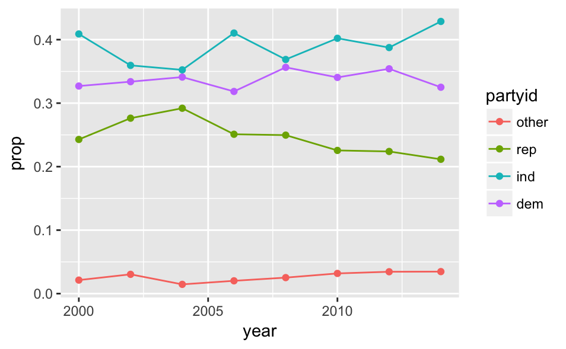

```r
gss_cat %>%
  mutate(partyid = fct_collapse(partyid,
    other = c("No answer", "Don't know", "Other party"),
    rep = c("Strong republican", "Not str republican"),
    ind = c("Ind,near rep", "Independent", "Ind,near dem"),
    dem = c("Not str democrat", "Strong democrat")
  )) %>%
  group_by(year, partyid) %>%
  count() %>%
  mutate(prop = n / sum(n)) %>%
  ggplot(aes(x = year, y = prop, colour = partyid)) +
    geom_line() +
    geom_point()
```

2. How could you collapse rincome into a small set of categories?

```r
levels(gss_cat$rincome)
```

```
 [1] "No answer"      "Don't know"     "Refused"
 [4] "$25000 or more" "$20000 - 24999" "$15000 - 19999"
 [7] "$10000 - 14999" "$8000 to 9999"  "$7000 to 7999"
[10] "$6000 to 6999"  "$5000 to 5999"  "$4000 to 4999"
[13] "$3000 to 3999"  "$1000 to 2999"  "Lt $1000"
[16] "Not applicable"
```

```r
gss_cat %>%
  mutate(rincome = fct_collapse(
    rincome,
    "Unknown" = c("No answer", "Don't know", "Refused"),
    "Lt $10000" = c("$8000 to 9999", "$7000 to 7999", "$6000 to 6999", "$5000 to 5999", "$4000 to 4999", "$3000 to 3999", "$1000 to 2999", "Lt $1000"),
    "$10000 to 19999" = c("$15000 - 19999", "$10000 - 14999"),
    "$20000 or more" = c("$25000 or more", "$20000 - 24999")
  )) %>%
  count(rincome)
```

| rincome | n |
| --- | --- |
| Unknown | 1425 |
| $20000 or more | 8646 |
| $10000 to 19999 | 2216 |
| Lt $10000 | 2153 |
| Not applicable | 7043 |